# QTM 385 Homework 2

Chelsey Kim, Ayah Noor Assaadi

10/21/2021

#### Problem 1: We derive the probability that a given observation is part of a bootstrap sample. Suppose that we obtain a bootstrap sample from a set of n observations

##### (a) What is the probability that the first bootstrap observation is not the first observation from the original sample? Justify your answer.

The probability that the first bootstrap observation is not the first observation is $1 - \dfrac{1}{n}$. This is because the probability of the first bootstrop is $\dfrac{1}{n}$, therefore, the probability of it not being the first observation would be 1 minus that probability.

##### (b) What is the probability that the second bootstrap observation is not the first observation from the original sample? Justify your answer.

The probability that the second bootstrap observation is not the first observation is $1 - \dfrac{1}{n}$. Just like the first bootstrap observation, the probability of the second bootstrap observation is $\dfrac{1}{n}$, therefore, the probability of it not being the second observation would be 1 minus that probability.

##### (c) When n = 10, what is the probability that the first observation is in the bootstrap sample?

$1 - (1 - \dfrac{1}{n})^n$

$1 - (1 - \dfrac{1}{10})^{10} = .6513215599$

##### (d) When n = 100, what is the probability that the first observation is in the bootstrap sample?

$1 - (1 - \dfrac{1}{100})^{100} = 0.6339677$

#### Problem 2: This question is based on the Boston housing data set. This data set has the information about housing values in 506 suburbs of Boston.

```r
library(boot)
library(MASS)
df <- Boston
```

##### (a) Based on this data set, provide an estimate for the population mean of crim (the crime rate by town). Call this estimate ū.

```r
mean_crime <- mean(df$crim)
mean_crime
```

```
## [1] 3.613524
```

##### (b) Provide an estimate of the standard error of û. Interpret this result.

```r
standard_error <- sd(df$crim) / sqrt(506)
standard_error
```

```
## [1] 0.3823853
```

##### (c) Now estimate the standard error of û using 1,000 bootstrap samples. How does this compare to your answer from (b)?

```r
set.seed(1)
boot.fn <- function(data, index) {
  return(mean(data[index]))
}
boot(df$crim, boot.fn, 1000)
```

```
##
## ORDINARY NONPARAMETRIC BOOTSTRAP
##
##
## Call:
## boot(data = df$crim, statistic = boot.fn, R = 1000)
##
##
## Bootstrap Statistics :
##     original      bias    std. error
## t1* 3.613524 -0.01246001   0.3709464
```

The standard error of û using the 1,000 bootstrap samples is 0.3709464, which is close to our estimate we found in (b) which was 0.3823853.

##### (d) Based on your bootstrap estimate from (c), provide a 95 % confidence interval for the mean of crim. Compare it to the results obtained using t.test(df$crim).

Confidence Interval: [û−2·se(û), û+2·se(û)]

```r
c(3.613524 - 2 * 0.3709464, 3.613524 + 2 * 0.3709464)
```

```
## [1] 2.871631 4.355417
```

```r
t.test(df$crim)
```

```
##
##  One Sample t-test
##
## data:  df$crim
## t = 9.45, df = 505, p-value < 2.2e-16
## alternative hypothesis: true mean is not equal to 0
## 95 percent confidence interval:
##  2.862262 4.364786
## sample estimates:
## mean of x
##  3.613524
```

The confidence interval that we calculated is [2.871631, 4.355417]. The confidence interval calculated by the t.test() function is [2.862262, 4.364786]. The difference between the two for both ends is 0.009369.

##### (e) Based on this data set, provide an estimate for the first quartile of crim. Call this quantity û0.25.

```r
quantile(df$crim, 0.25)
```

```
##      25%
## 0.082045
```

û0.25 = 0.082045

##### (f) We now would like to estimate the standard error of û0.25. Comment on your findings.

```r
boot.fn1 <- function(data, index) {
  mu <- quantile(data[index], .25)
    return (mu)
}
boot(df$crim, boot.fn1, 1000)
```

```
##
## ORDINARY NONPARAMETRIC BOOTSTRAP
##
##
## Call:
## boot(data = df$crim, statistic = boot.fn1, R = 1000)
##
##
## Bootstrap Statistics :
##     original        bias    std. error
## t1* 0.082045 -0.0005841025 0.006869886
```

##### (g) Consider a linear regression model to predict crim using rad (index of accessibility to radial highways). Compute estimates for the standard errors of the intercept β0 and coefficient β1 of rad in two different ways: (1) using the bootstrap, and (2) using the standard formula for computing the standard errors in the lm() function. Comment on your findings.

```r
linear_regression_model <- lm(crim ~ rad, data=df)
summary(linear_regression_model)
```

```
##
## Call:
## lm(formula = crim ~ rad, data = df)
##
## Residuals:
##     Min      1Q  Median      3Q     Max
## -10.164  -1.381  -0.141   0.660  76.433
##
## Coefficients:
##             Estimate Std. Error t value Pr(>|t|)
## (Intercept) -2.28716    0.44348  -5.157 3.61e-07 ***
## rad          0.61791    0.03433  17.998  < 2e-16 ***
## ---
## Signif. codes:  0 '***' 0.001 '**' 0.01 '*' 0.05 '.' 0.1 ' ' 1
##
## Residual standard error: 6.718 on 504 degrees of freedom
## Multiple R-squared:  0.3913, Adjusted R-squared:   0.39
## F-statistic: 323.9 on 1 and 504 DF,  p-value: < 2.2e-16
```

```r
boot.fn2 <- function(data, index) {
return(coef(lm(crim ~ rad, data = df, subset = index)))
}

boot(df$crim, boot.fn2, 1000)
```

```
##
## ORDINARY NONPARAMETRIC BOOTSTRAP
##
##
## Call:
## boot(data = df$crim, statistic = boot.fn2, R = 1000)
##
##
## Bootstrap Statistics :
##       original       bias    std. error
## t1* -2.2871594  0.008084645  0.24970430
## t2*  0.6179109 -0.002407227  0.05568156
```

#### Problem 3: We will now perform cross-validation on a simulated data set.

```r
set.seed(123)
x <- rnorm(200)
y <- x + x**2 + x**3 + 0.5 * rnorm(200)
```

##### (a) Use the regsubsets() function in the leaps library to perform best subset selection in order to choose the best model containing the predictors X, X2, … , X10. What is the best model obtained according to Cp, BIC, and adjusted R2? Show some plots to provide evidence for your answer, and report the coefficients of the best model obtained.

```r
which.min(summary$cp)
```

```
## [1] 3
```

```r
which.min(summary$bic)
```

```
## [1] 3
```

```r
which.max(summary$adjr2)
```

```
## [1] 3
```

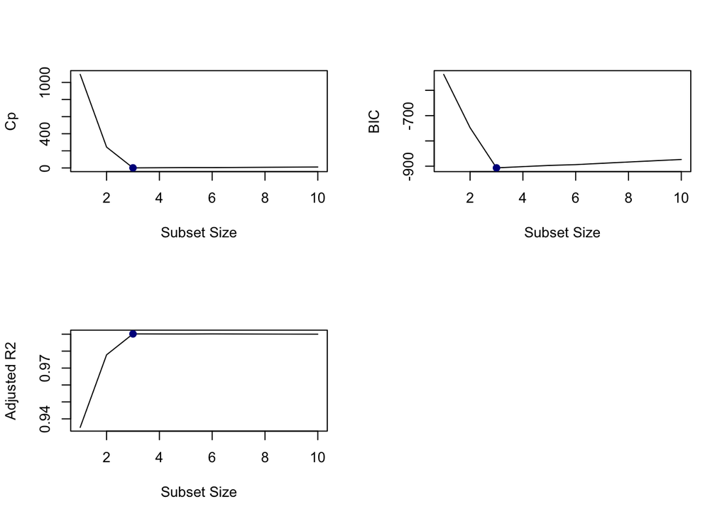

```r
par(mfrow=c(2, 2))

plot(summary$cp, xlab="Subset Size", ylab="Cp", pch=20, type="l")
points(3, summary$cp[3], pch=19, col="darkblue", lwd=1)

plot(summary$bic, xlab="Subset Size", ylab="BIC", pch=20, type="l")
points(3, summary$bic[3], pch=19, col="darkblue", lwd=1)

plot(summary$adjr2, xlab="Subset Size", ylab="Adjusted R2", pch=20, type="l")
points(3, summary$adjr2[3], pch=19, col="darkblue", lwd=1)
```

```r
coef(regsubset,which.min(summary$bic))
```

```
##              (Intercept) poly(x, 10, raw = TRUE)1 poly(x, 10, raw = TRUE)2
##              -0.01643952               0.93421353               1.03743137
## poly(x, 10, raw = TRUE)3
##               1.01411542
```

For all the Cp, BIC, and adjusted R2, we pick the 3-variables model.

##### (b) Repeat (a), using forward stepwise selection and also using backwards stepwise selection. How does your answer compare to the results in (a)?

```r
forward <-  regsubsets(y ~ poly(x, 10, raw=TRUE), data = data.frame, nvmax = 10, method="forward")
forward.summary <-  summary(forward)
```

```r
which.min(forward.summary$cp)
```

```
## [1] 3
```

```r
which.min(forward.summary$bic)
```

```
## [1] 3
```

```r
which.max(forward.summary$adjr2)
```

```
## [1] 3
```

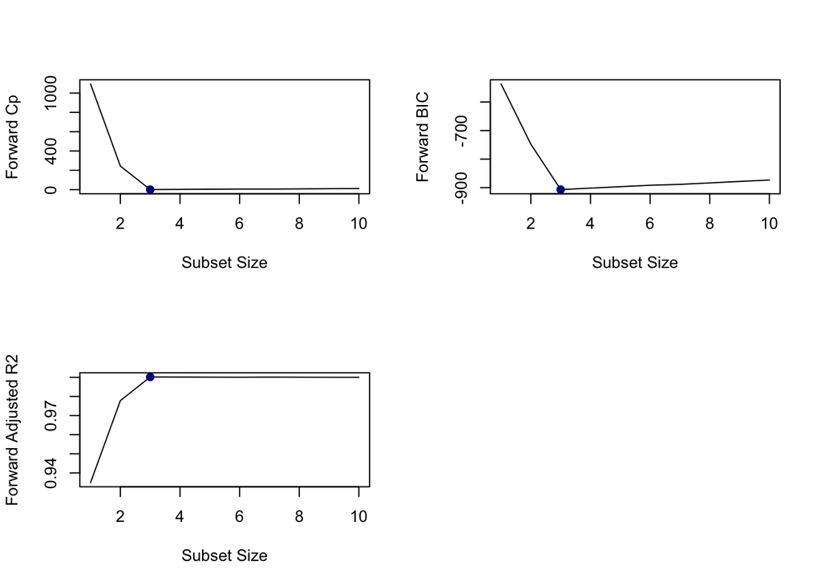

```r
par(mfrow=c(2, 2))

plot(forward.summary$cp, xlab="Subset Size", ylab="Forward Cp", pch=20, type="l")
points(3, forward.summary$cp[3], pch=19, col="darkblue", lwd=1)

plot(forward.summary$bic, xlab="Subset Size", ylab="Forward BIC", pch=20, type="l")
points(3, forward.summary$bic[3], pch=19, col="darkblue", lwd=1)

plot(forward.summary$adjr2, xlab="Subset Size", ylab="Forward Adjusted R2", pch=20, type="l")
points(3, forward.summary$adjr2[3], pch=19, col="darkblue", lwd=1)
```

```r
backward <-  regsubsets(y ~ poly(x, 10, raw=TRUE), data = data.frame, nvmax=10, method="backward")

backward.summary <-  summary(backward)
```

```r
which.min(backward.summary$cp)
```

```
## [1] 3
```

```r
which.min(backward.summary$bic)
```

```
## [1] 3
```

```r
which.max(backward.summary$adjr2)
```

```
## [1] 3
```

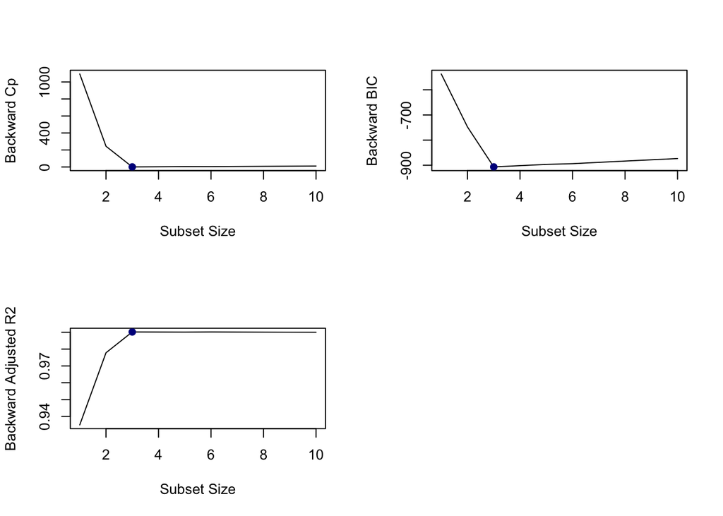

```r
par(mfrow=c(2, 2))

plot(backward.summary$cp, xlab="Subset Size", ylab="Backward Cp", pch=20, type="l")
points(3, backward.summary$cp[3], pch=19, col="darkblue", lwd=1)

plot(backward.summary$bic, xlab="Subset Size", ylab="Backward BIC", pch=20, type="l")
points(3, backward.summary$bic[3], pch=19, col="darkblue", lwd=1)

plot(backward.summary$adjr2, xlab="Subset Size", ylab="Backward Adjusted R2", pch=20, type="l")
points(3, backward.summary$adjr2[3], pch=19, col="darkblue", lwd=1)
```

Like in (a), all the Cp, BIC, and adjusted R2 for both the forward and backward stepwise selection we pick the 3-variable model.

##### (c) Now fit a lasso model to the simulated data, again using X, X2, · · · , X10 as predictors. Use cross-validation to select the optimal value of λ. Create plots of the cross-validation error as a function of λ. Report the coefficient estimates using the optimal λ on the entire data, and discuss the results obtained.

```r
set.seed(123)
x1=cbind(x,x^2,x^3,x^4,x^5,x^6,x^7,x^8,x^9,x^10)
y1=y
```

```r
# Cross-validation to select optimal value of λ
lasso = cv.glmnet(x1,y1, alpha=1)
lasso$lambda.min
```

```
## [1] 0.05067152
```

```r
lasso$lambda.1se
```

```
## [1] 0.09718342
```

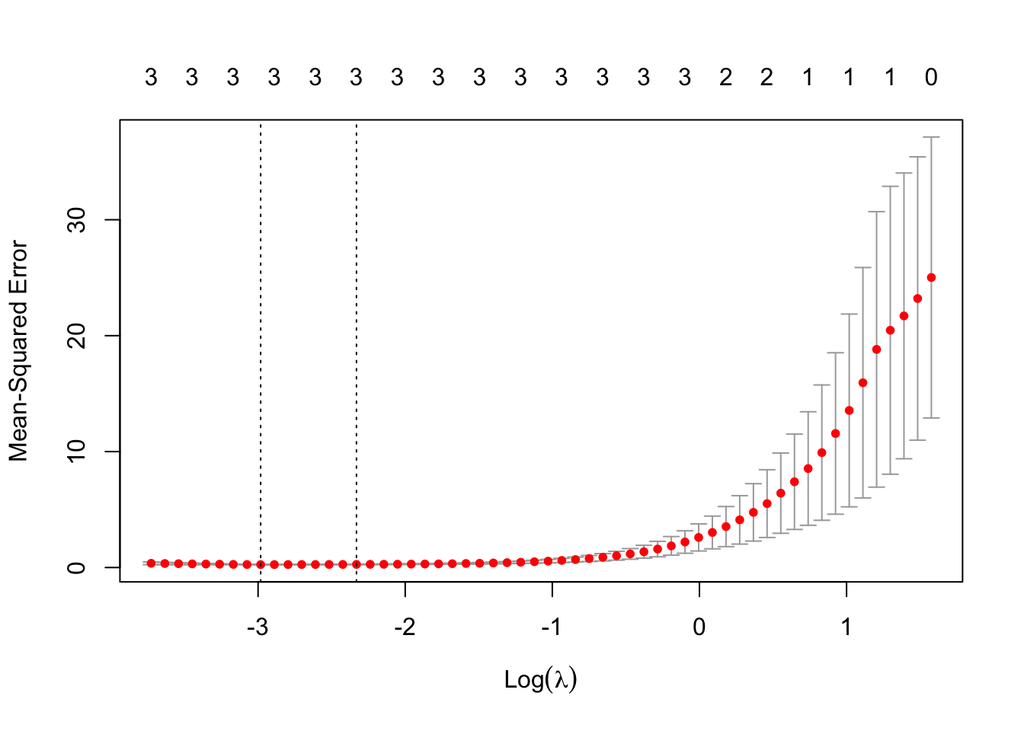

```r
# Plot of the cross-validation error as a function of λ
plot(lasso)
```

```r
# Coefficient estimates using the optimal λ on the entire data
lasso_model =glmnet(x1,y1,alpha=1, lambda= lasso$lambda.min)
coef(lasso_model)[,1]
```

[output not shown]

With the value of λ giving the minimum cv error, the Lasso shrinks the majority predictors to zero at X3.

#### Problem 4: This question is based on the College data set. This data set has statistics for a large number of US Colleges from the 1995 issue of US News and World Report. You can find the description of this data set at https://rdrr.io/cran/ISLR/man/College.html.

```r
df <- College
df$Accept.Rate <- df$Accept/df$Apps
df <- subset(df, select = -c(Accept, Apps))
```

##### (a) Split the data into a training set and a test set with 80% observations in the training set and 20% observations in the test set.

```r
train <- sample(nrow(df) * 0.8)
train_set <- df[train, ]
test_set <- df[-train, ]
```

##### (b) Fit a linear model using least squares on the training set, and report the test error obtained.

```r
linear_model <- lm(Accept.Rate ~ ., data = train_set)
pred <- predict(linear_model, test_set)
summary(linear_model)
```

```
##
## Call:
## lm(formula = Accept.Rate ~ ., data = train_set)
##
## Residuals:
##      Min       1Q   Median       3Q      Max
## -0.56557 -0.07058  0.01445  0.08602  0.33866
##
## Coefficients:
##               Estimate Std. Error t value Pr(>|t|)
## (Intercept)  1.059e+00  5.230e-02  20.259  < 2e-16 ***
## PrivateYes   8.175e-02  1.872e-02   4.367 1.48e-05 ***
## Enroll       4.418e-05  2.066e-05   2.138  0.03294 *
## Top10perc   -2.434e-03  7.136e-04  -3.411  0.00069 ***
## Top25perc   -6.150e-04  5.773e-04  -1.065  0.28718
## F.Undergrad -2.999e-06  4.219e-06  -0.711  0.47741
## P.Undergrad -1.355e-05  5.707e-06  -2.375  0.01788 *
## Outstate     5.086e-06  2.439e-06   2.086  0.03743 *
## Room.Board  -2.629e-05  6.142e-06  -4.281 2.17e-05 ***
## Books       -9.138e-05  3.029e-05  -3.017  0.00266 **
## Personal     8.577e-06  8.381e-06   1.023  0.30655
## PhD          1.517e-04  5.883e-04   0.258  0.79656
## Terminal     2.503e-04  6.437e-04   0.389  0.69751
## S.F.Ratio   -5.042e-03  1.708e-03  -2.953  0.00327 **
## perc.alumni  6.740e-04  5.315e-04   1.268  0.20529
## Expend      -8.891e-06  1.711e-06  -5.198 2.76e-07 ***
## Grad.Rate   -1.113e-03  3.753e-04  -2.965  0.00315 **
## ---
## Signif. codes:  0 '***' 0.001 '**' 0.01 '*' 0.05 '.' 0.1 ' ' 1
##
## Residual standard error: 0.1209 on 604 degrees of freedom
## Multiple R-squared:  0.3541, Adjusted R-squared:  0.3369
## F-statistic: 20.69 on 16 and 604 DF,  p-value: < 2.2e-16
```

```r
(linear_info <- postResample(pred, test_set$Accept.Rate))
```

```
##       RMSE   Rsquared        MAE
## 0.11446418 0.33958515 0.08992106
```

The test error obtained is MAE: 0.0899

##### (c) Fit a ridge regression model on the training set, with λ chosen by cross-validation. Report the test error obtained.

```r
xtrain=model.matrix (Accept.Rate~.,train_set)[,-1]
ytrain=train_set$Accept.Rate
xtest=model.matrix (Accept.Rate~.,test_set)[,-1]
ytest=test_set$Accept.Rate
ridge_fit <- train(x = xtrain, y = ytrain,
                   method = 'glmnet',
                   trControl = trainControl(method = 'cv', number = 10),
                   tuneGrid = expand.grid(alpha = 0,
                                          lambda = seq(0, 10e2, length.out = 20)))

(ridge_info <- postResample(predict(ridge_fit, xtest), ytest))
```

```
##       RMSE   Rsquared        MAE
## 0.11390531 0.34379854 0.09009663
```

```r
coef(ridge_fit$finalModel, ridge_fit$bestTune$lambda)
```

```
## 17 x 1 sparse Matrix of class "dgCMatrix"
##                        s1
## (Intercept)  1.055045e+00
## PrivateYes   7.693451e-02
## Enroll       2.670696e-05
## Top10perc   -2.134343e-03
## Top25perc   -7.700194e-04
## F.Undergrad -4.007439e-07
## P.Undergrad -1.260002e-05
## Outstate     4.015614e-06
## Room.Board  -2.441523e-05
## Books       -8.995324e-05
## Personal     7.311757e-06
## PhD          8.166997e-05
## Terminal     1.963911e-04
## S.F.Ratio   -4.422938e-03
## perc.alumni  6.681049e-04
## Expend      -7.967199e-06
## Grad.Rate   -1.000693e-03
```

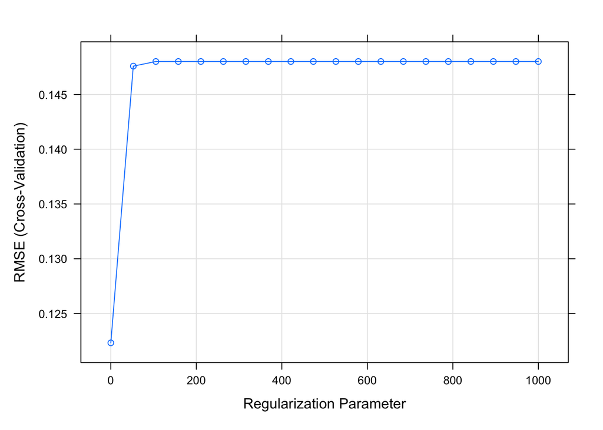

```r
plot(ridge_fit)
```

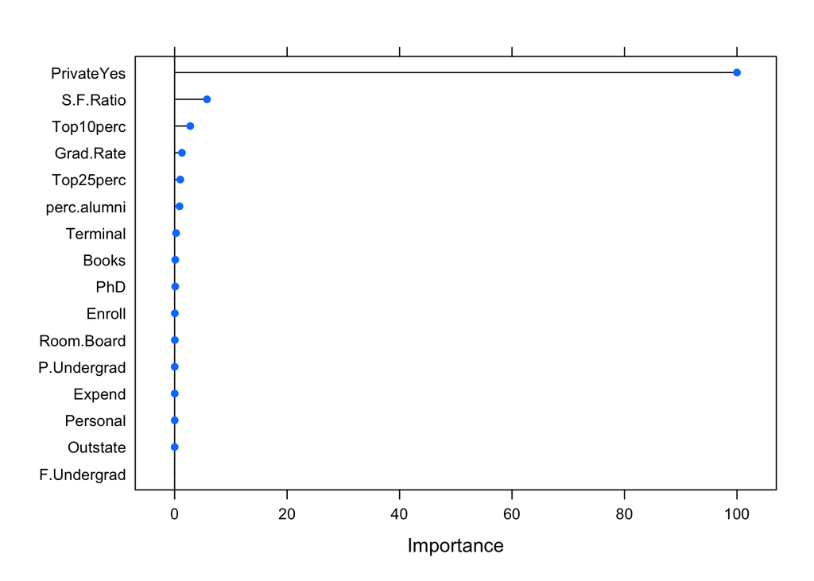

```r
plot(varImp(ridge_fit))
```

The test error obtained is MAE: 0.0901

##### (d) Fit a lasso model on the training set, with λ chosen by cross-validation. Report the test error obtained, along with the number of non-zero coefficient estimates.

```r
lasso_fit <- train(x = xtrain, y = ytrain,
                   method = 'glmnet',
                   trControl = trainControl(method = 'cv', number = 10),
                   tuneGrid = expand.grid(alpha = 1,
                                          lambda = seq(0.0001, 1, length.out = 50)))

(lasso_info <- postResample(predict(lasso_fit, xtest), ytest))
```

```
##       RMSE   Rsquared        MAE
## 0.11436376 0.34048716 0.08992105
```

```r
coef(lasso_fit$finalModel, lasso_fit$bestTune$lambda)
```

```
## 17 x 1 sparse Matrix of class "dgCMatrix"
##                        s1
## (Intercept)  1.059033e+00
## PrivateYes   8.170504e-02
## Enroll       4.053372e-05
## Top10perc   -2.433889e-03
## Top25perc   -6.068059e-04
## F.Undergrad -2.327098e-06
## P.Undergrad -1.349576e-05
## Outstate     4.991828e-06
## Room.Board  -2.615970e-05
## Books       -9.091833e-05
## Personal     8.227827e-06
## PhD          1.440769e-04
## Terminal     2.361127e-04
## S.F.Ratio   -4.990922e-03
## perc.alumni  6.662497e-04
## Expend      -8.788579e-06
## Grad.Rate   -1.096353e-03
```

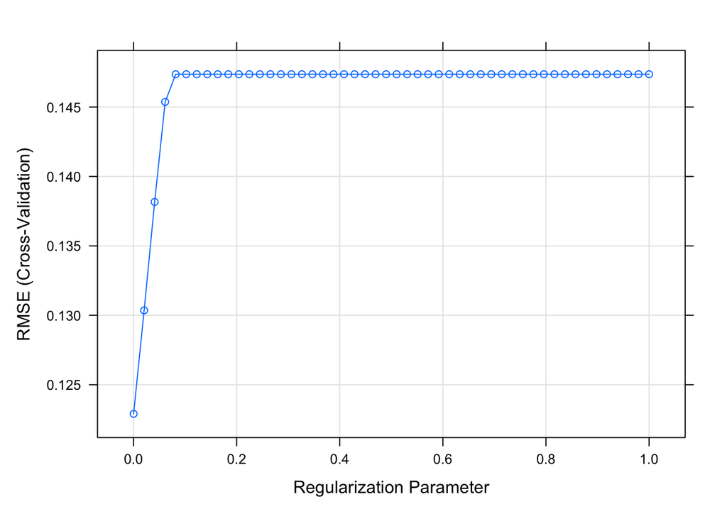

```r
plot(lasso_fit)
```

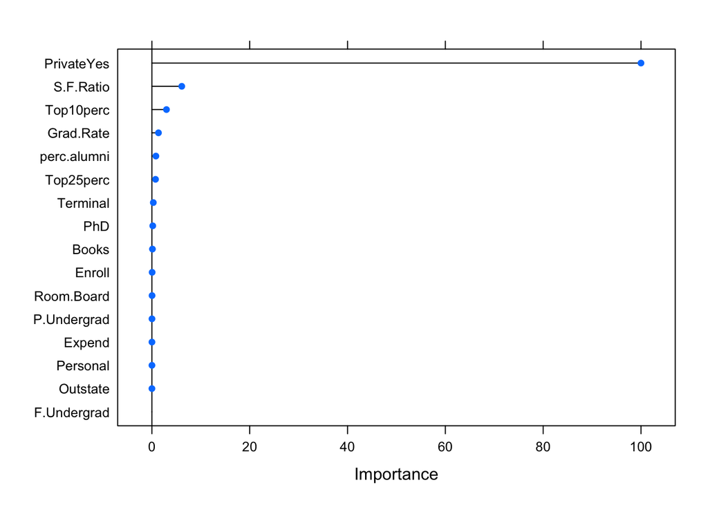

```r
plot(varImp(lasso_fit))
```

The test error obtained is MAE: 0.0899, and the number of non-zero coefficient estimates is in the R-Markdown.

##### (e) Fit a PCR model on the training set, with M chosen by cross-validation. Report the test error obtained, along with the value of M selected by cross-validation.

```r
pcr_model <- train(x = xtrain, y = ytrain,
                   method = 'pcr',
                   trControl = trainControl(method = 'cv', number = 10),
                   tuneGrid = expand.grid(ncomp = 1:10))
(pcr_info <- postResample(predict(pcr_model, xtest), ytest))
```

```
##       RMSE   Rsquared        MAE
## 0.11813979 0.30622578 0.09160964
```

```r
coef(pcr_model$finalModel)
```

```
## , , 10 comps
##
##                  .outcome
## PrivateYes  -1.649401e-06
## Enroll       4.437216e-05
## Top10perc   -1.071756e-03
## Top25perc   -1.409478e-03
## F.Undergrad -7.623430e-06
## P.Undergrad -1.579739e-05
## Outstate     1.127794e-05
## Room.Board  -2.639596e-05
## Books       -9.241964e-05
## Personal     9.468934e-06
## PhD         -1.463520e-04
## Terminal    -7.028675e-05
## S.F.Ratio    1.124138e-05
## perc.alumni -3.171868e-04
## Expend      -8.361914e-06
## Grad.Rate   -8.345690e-04
```

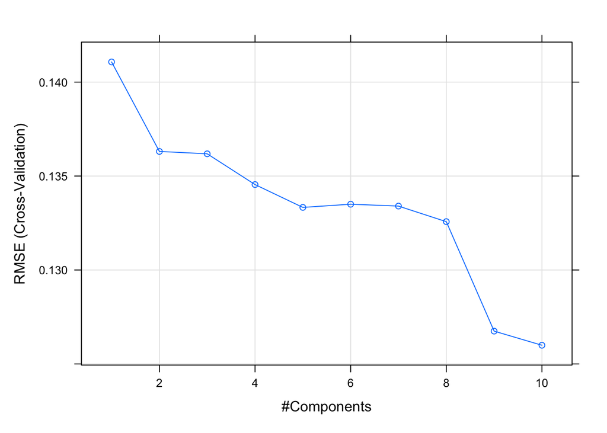

```r
plot(pcr_model)
```

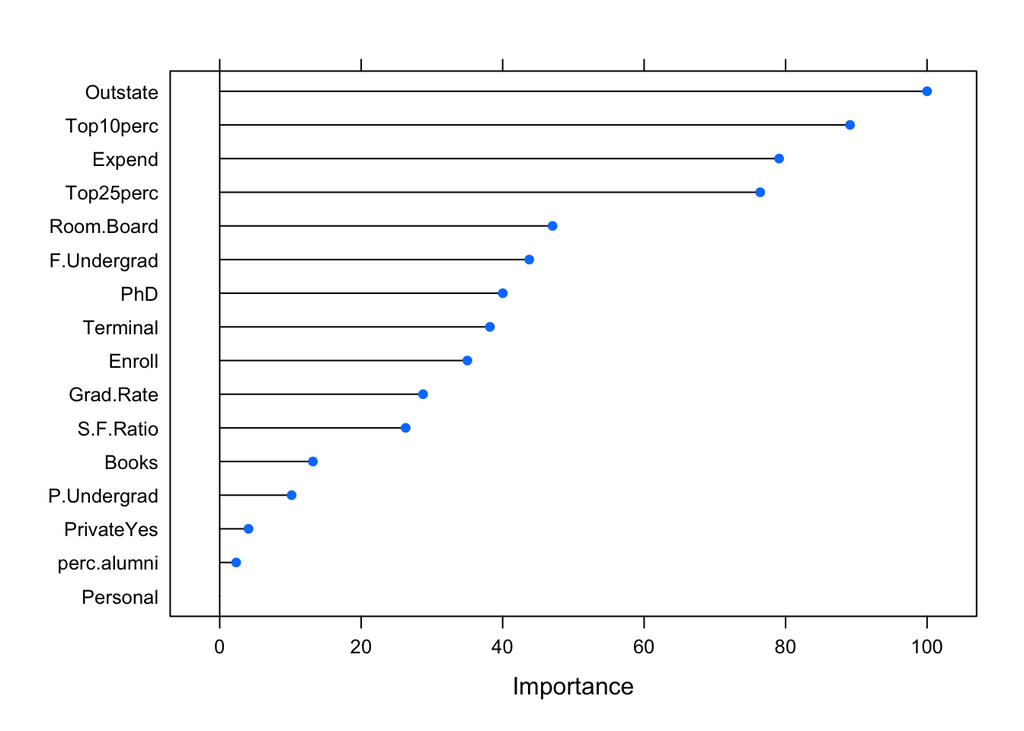

```r
plot(varImp(pcr_model))
```

The test error obtained is MAE: 0.0916, and value of M selected by cross-validation is in the R-Markdown

##### (f) Fit a PLS model on the training set, with M chosen by cross-validation. Report the test error obtained, along with the value of M selected by cross-validation.

```r
pls_model <- train(x = xtrain, y = ytrain,
                   method = 'pls',
                   trControl = trainControl(method = 'cv', number = 10),
                   tuneGrid = expand.grid(ncomp = 1:10))
(pls_info <- postResample(predict(pls_model, xtest), ytest))
```

```
##       RMSE   Rsquared        MAE
## 0.11631321 0.32430005 0.09064626
```

```r
coef(pls_model$finalModel)
```

```
## , , 10 comps
##
##                  .outcome
## PrivateYes   5.978098e-05
## Enroll       4.556714e-05
## Top10perc   -1.544922e-03
## Top25perc   -1.304375e-03
## F.Undergrad -7.548443e-06
## P.Undergrad -1.583771e-05
## Outstate     1.037905e-05
## Room.Board  -2.520684e-05
## Books       -9.008411e-05
## Personal     1.059273e-05
## PhD         -5.419064e-05
## Terminal     1.707228e-04
## S.F.Ratio   -5.021246e-04
## perc.alumni  5.806074e-04
## Expend      -8.391777e-06
## Grad.Rate   -1.102640e-03
```

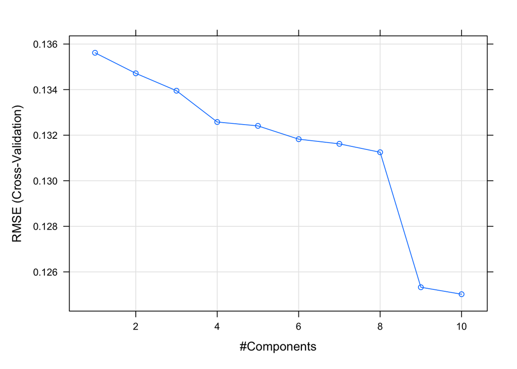

```r
plot(pls_model)
```

The test error obtained is MAE: 0.0906, and value of M selected by cross-validation is in the R-Markdown

#### Problem 5: Problem 5 This problem continues with Problem 4 to predict the acceptance rate using all variables other than Accept and Apps. You can use the same training and test sets as Problem 4.

##### (a) Fit a regression tree to the training set. Plot the tree, and interpret the results. What test MSE do you obtain?

```r
reg.tree = tree(Accept.Rate ~ ., data = train_set)
summary(reg.tree)
```

```
##
## Regression tree:
## tree(formula = Accept.Rate ~ ., data = train_set)
## Variables actually used in tree construction:
## [1] "Top25perc"   "F.Undergrad" "Outstate"    "Grad.Rate"   "Room.Board"
## Number of terminal nodes:  11
## Residual mean deviance:  0.01063 = 6.485 / 610
## Distribution of residuals:
##     Min.  1st Qu.   Median     Mean  3rd Qu.     Max.
## -0.48090 -0.06256  0.01065  0.00000  0.06947  0.21660
```

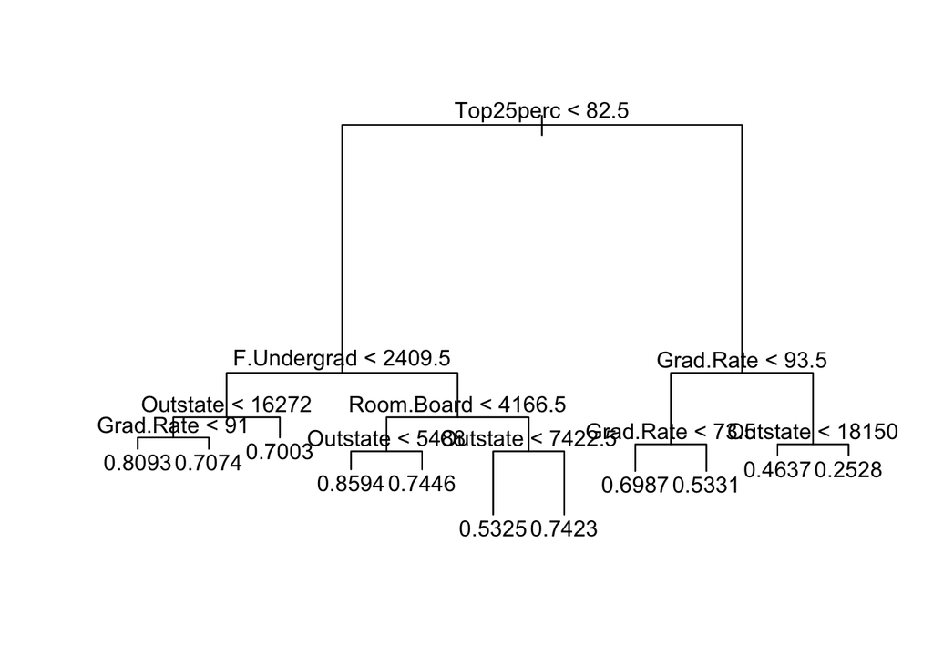

```r
plot(reg.tree)
text(reg.tree, pretty = 0)
```

```r
yhat = predict(reg.tree,newdata = test_set)
mean((yhat - test_set$Accept.Rate)^2)
```

```
## [1] 0.0154667
```

We can conclude that the Test MSE is about 0.0155.

##### (b) Use cross-validation in order to determine the optimal level of tree complexity. Does pruning the tree improve the test MSE?

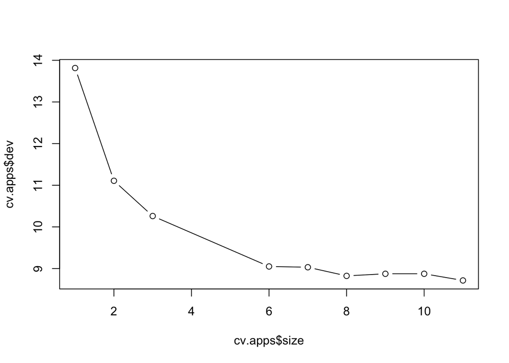

```r
set.seed(1)
cv.apps = cv.tree(reg.tree)
plot(cv.apps$size, cv.apps$dev, type = "b")
```

```r
best_tree_size <- cv.apps$size[which.min(cv.apps$dev)]
best_tree_size
```

```
## [1] 11
```

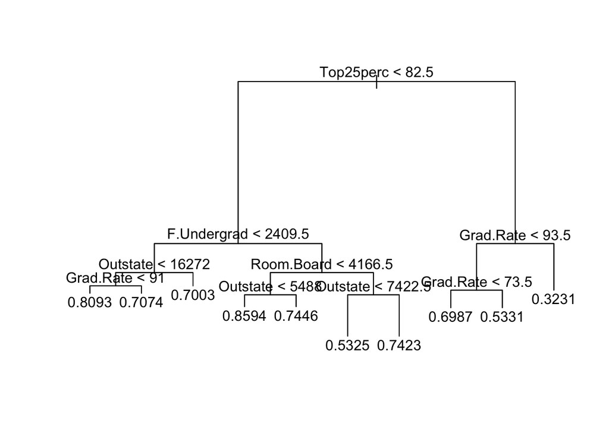

```r
prune.apps = prune.tree(reg.tree, best = 10)
plot(prune.apps)
text(prune.apps,pretty=0)
```

```r
yhat=predict(prune.apps, newdata= test_set)
mean((yhat-test_set$Accept.Rate)^2)
```

```
## [1] 0.01557136
```

##### (c) Use the bagging approach in order to analyze this data. What test MSE do you obtain? Use the importance() function to determine which variables are most important.

```r
p <- dim(df)[2]-1
bagging <- randomForest(Accept.Rate~., data = train_set, importance = T, mtry = p, ntree = 500)
bagging_pred <- predict(bagging, test_set)
importance(bagging)
```

```
##               %IncMSE IncNodePurity
## Private      4.178035    0.03350006
## Enroll       8.750671    0.37074314
## Top10perc   16.408661    1.53440975
## Top25perc   26.636325    3.01966327
## F.Undergrad 15.327017    0.77017348
## P.Undergrad  9.269930    0.52133326
## Outstate    32.053096    1.79425659
## Room.Board  25.599652    1.00051030
## Books        8.659699    0.64746387
## Personal     4.329626    0.42068052
## PhD          8.567844    0.33093100
## Terminal     5.021281    0.36394442
## S.F.Ratio    2.188295    0.42010199
## perc.alumni  1.188034    0.36532813
## Expend      10.363026    0.56649686
## Grad.Rate   21.466970    1.22937526
```

```r
mean((bagging_pred-test_set$Accept.Rate)^2)
```

```
## [1] 0.01096391
```

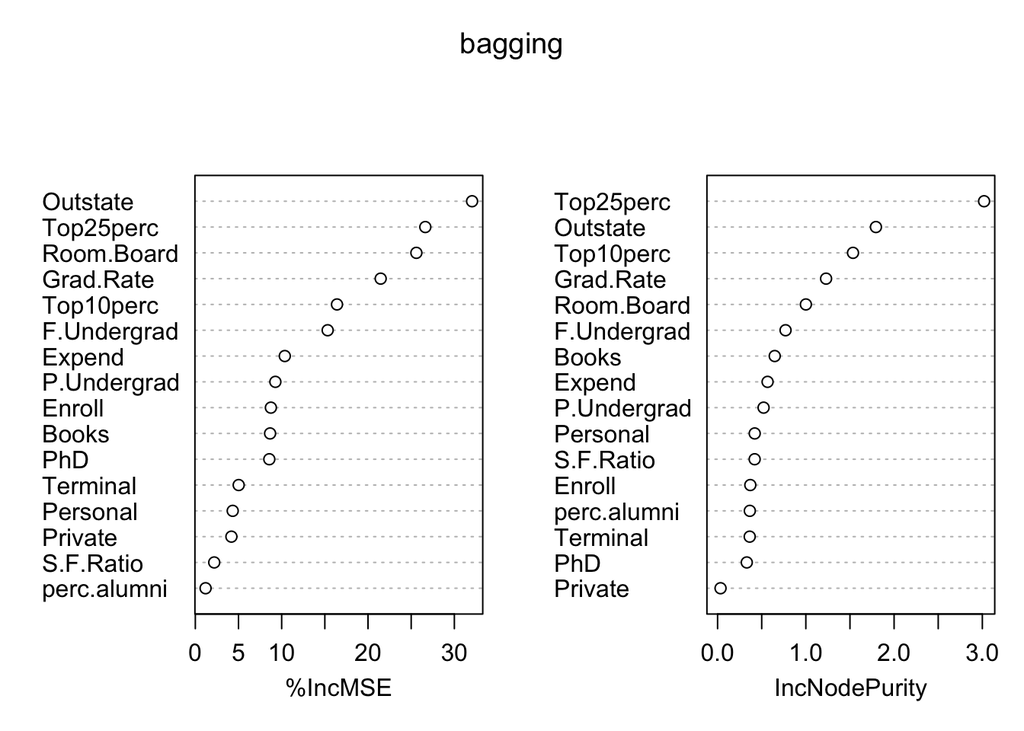

```r
varImpPlot(bagging)
```

##### (d) Use random forests to analyze this data. What test MSE do you obtain? Use the importance() function to determine which variables are most important. Describe the effect of m, the number of variables considered at each split, on the error rate obtained.

```r
MSE_list <- sapply(1:(p-1), function(i){
  randomF <- randomForest(Accept.Rate~., data = train_set, importance = T, mtry = i, ntree = 500)
  randomF_pred <- predict(randomF, test_set)
  mean((randomF_pred-test_set$Accept.Rate)^2)
})
minNbrTrees <- which.min(MSE_list)
min(MSE_list)
```

```
## [1] 0.01070609
```

```r
minNbrTrees
```

```
## [1] 6
```

```r
randomF <- randomForest(Accept.Rate~., data = train_set, importance = T, mtry = minNbrTrees, ntree = 500)
importance(randomF)
```

```
##               %IncMSE IncNodePurity
## Private      7.174509     0.1022730
## Enroll      10.815986     0.4946992
## Top10perc   16.311548     1.6521823
## Top25perc   20.251812     1.9638884
## F.Undergrad 12.781065     0.7477168
## P.Undergrad  9.521744     0.5475189
## Outstate    24.772772     1.7558049
## Room.Board  19.814868     0.9225619
## Books       10.438321     0.6741231
## Personal     5.203161     0.4276050
## PhD          8.331077     0.4339642
## Terminal     7.652709     0.5356997
## S.F.Ratio    3.352328     0.4885943
## perc.alumni  4.283590     0.4175899
## Expend      12.776870     0.9261508
## Grad.Rate   17.713263     1.0686323
```